# Evolutionary Dynamics - Exercise 1

by Daniel Dugas, Florian Tschopp, and Michel Breyer

```python
import matplotlib.pyplot as plt
import numpy as np
import sympy
from sympy.solvers import solve
from sympy import Symbol, Function
from IPython.display import display
```

## Problem 1: Logistic difference equation

> In a discrete time model for population growth, the value $x$ (number of cells divided by the maximum number supported by the habitat) at time $t + 1$ is calculated from the value at time $t$ according to the difference equation $$x_{t+1} = r x_t(1−x_t).$$

We will use `sympy` to derive symbolic solutions. First, we define the update function:

```python
xt = Symbol('x_t')
r = Symbol('r')
def f_(r, xt):
    return r * xt * (1 - xt)
f = f_(r, xt)
display(f)
```

$\displaystyle r x_{t} \left(1 - x_{t}\right)$

Thus the derivative of the update function is:

```python
fprime = sympy.simplify(sympy.diff(f, xt))
display(fprime)
```

$\displaystyle r \left(1 - 2 x_{t}\right)$

### (a) Determine the equilibrium points $x^*$ of the system

We find the equilibrium points by solving $f(x)=x$ for $x$.

```python
equilibrium_points =  sympy.solve(f - xt, xt)

print("Equilibrium points x*:")
for x_star in equilibrium_points:
    display(x_star)
```

```
Equilibrium points x*:
```

$\displaystyle 0$

$\displaystyle \frac{r - 1}{r}$

Note that the solution $x^* = (r - 1)/r$ only exists if $r \neq 0$.

### (b) Are the points stable for $r = 0.5$, $r = 1.5$, $r = 2.5$?

The condition for stability is $|f'(x^*)|<1$. In our case,

```python
r_values = [0.5, 1.5, 2.5]
for ri in r_values:
  print("r = {},".format(ri))
  for xi in equilibrium_points:
    xi = float(xi.subs(r, ri))
    fpi = fprime.subs(xt, xi).subs(r, ri)
    is_stable = abs(fpi) < 1
    print("  x* = {:>5.2f} : f' = {:>5.2f} -> equilibrium point is {}stable".format(xi, fpi, '' if is_stable else 'un'))
```

```
r = 0.5,
  x* =  0.00 : f' =  0.50 -> equilibrium point is stable
  x* = -1.00 : f' =  1.50 -> equilibrium point is unstable
r = 1.5,
  x* =  0.00 : f' =  1.50 -> equilibrium point is unstable
  x* =  0.33 : f' =  0.50 -> equilibrium point is stable
r = 2.5,
  x* =  0.00 : f' =  2.50 -> equilibrium point is unstable
  x* =  0.60 : f' = -0.50 -> equilibrium point is stable
```

### (c) Confirm this by numerically iterating the difference equation.

For each value of $r$, we iterate the difference equation for $100$ steps with initial conditions close to the two fixed points.

```python
r_values = [0.5, 1.5, 2.5]
for ri in r_values:
  print("r = {},".format(ri))
  for xi in equilibrium_points:
    xi = float(xi.subs(r, ri))
    fpi = fprime.subs(xt, xi).subs(r, ri)
    is_stable = fpi > 0
    print("  x* = {:>5.2f} :".format(xi))
    t = 0
    eps = 0.01
    x_t = xi + eps
    print("    Initial x = {}, (epsilon = {})".format(x_t, eps))
    for t in range(100):
        x_t = float(f.subs(r, ri).subs(xt, x_t))
    is_close = ( x_t - xi ) < eps
    is_close_string = "" if is_close else " -> has shifted from starting equilibrium!"
    print("    After {} iterations, x = {:.2f}{}".format(t+1, x_t, is_close_string))
```

```
r = 0.5,
  x* =  0.00 :
    Initial x = 0.01, (epsilon = 0.01)
    After 100 iterations, x = 0.00
  x* = -1.00 :
    Initial x = -0.99, (epsilon = 0.01)
    After 100 iterations, x = -0.00 -> has shifted from starting equilibrium!
r = 1.5,
  x* =  0.00 :
    Initial x = 0.01, (epsilon = 0.01)
    After 100 iterations, x = 0.33 -> has shifted from starting equilibrium!
  x* =  0.33 :
    Initial x = 0.3433333333333333, (epsilon = 0.01)
    After 100 iterations, x = 0.33
r = 2.5,
  x* =  0.00 :
    Initial x = 0.01, (epsilon = 0.01)
    After 100 iterations, x = 0.60 -> has shifted from starting equilibrium!
  x* =  0.60 :
    Initial x = 0.6100000000000001, (epsilon = 0.01)
    After 100 iterations, x = 0.60
```

We observe that the sequences diverge from the repelling fixed points.

### (d) Examine the stability and behaviour for $r = 3.5$.

> Hint: Plot the Poincaré section of $x_t$ against $x_{t−1}$, and remove transient points.

First, we examine the derivative at the equilibrium points.

```python
r_values = [3.5]
for ri in r_values:
  print("r = {},".format(ri))
  for xi in equilibrium_points:
    xi = float(xi.subs(r, ri))
    fpi = fprime.subs(xt, xi).subs(r, ri)
    is_stable = abs(fpi) < 1
    print("  x* = {:>5.2f} : f' = {:>5.2f} -> equilibrium point is {}stable".format(xi, fpi, '' if is_stable else 'un'))
```

```
r = 3.5,
  x* =  0.00 : f' =  3.50 -> equilibrium point is unstable
  x* =  0.71 : f' = -1.50 -> equilibrium point is unstable
```

We see that for $r = 3.5$, both equilibrium points are unstable.

Tracing two sequences on a Poincaré plot also shows that the paths diverge from the fixed points.

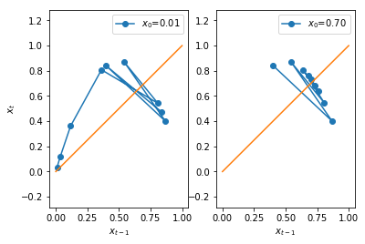

```python
N = 10
xs1, xs2 = np.zeros(N), np.zeros(N)

xs1[0] = 0.01
xs2[0] = 0.70

for t in range(N-1):
    xs1[t+1] = f_(3.5, xs1[t])
    xs2[t+1] = f_(3.5, xs2[t])

fig, (ax1, ax2) = plt.subplots(1, 2)

ax1.plot(xs1[:-1], xs1[1:], 'o-', label='$x_0$=0.01')
ax1.plot([0, 1], [0, 1])
ax1.set_xlabel('$x_{t-1}$')
ax1.set_ylabel('$x_{t}$')
ax1.axis('equal')
ax1.legend()

ax2.plot(xs2[:-1], xs2[1:], 'o-', label='$x_0$=0.70')
ax2.plot([0, 1], [0, 1])
ax2.set_xlabel('$x_{t-1}$')
ax2.axis('equal')
ax2.legend()

plt.show()
```

### (e) What happens for $r = 3.9$?

Again, we compute the derivative at $x^*$ for $r=3.9$.

```python
ri = 3.9
print("r = {},".format(ri))

for xi in equilibrium_points:
    xi = float(xi.subs(r, ri))
    fpi = float(fprime.subs(xt, xi).subs(r, ri))
    is_stable = abs(fpi) < 1
    print("  x* = {:>5.2f} : f' = {:>5.2f} -> equilibrium point is {}stable".format(xi, fpi, '' if is_stable else 'un'))
```

```
r = 3.9,
  x* =  0.00 : f' =  3.90 -> equilibrium point is unstable
  x* =  0.74 : f' = -1.90 -> equilibrium point is unstable
```

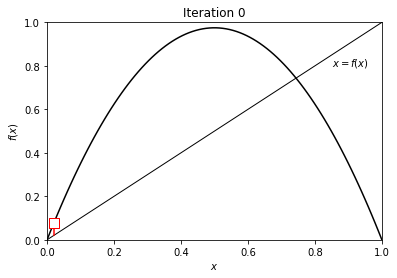

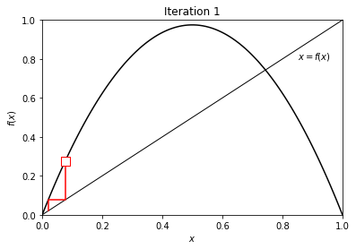

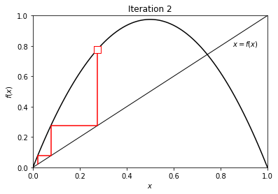

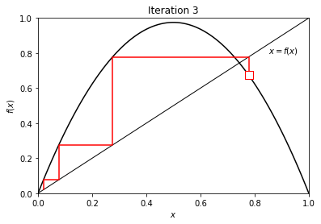

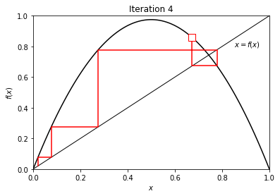

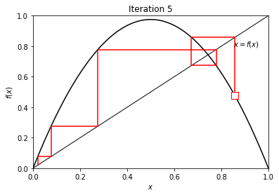

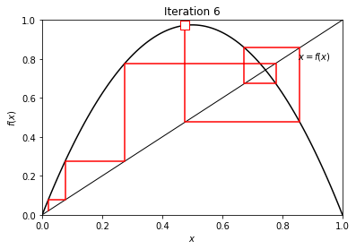

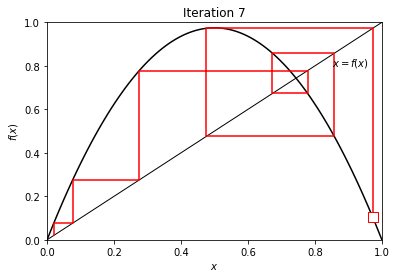

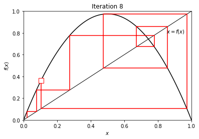

```python
x = np.linspace(0.0, 1.0, 100)
fx = f_(ri, x)

# Iterate
N = 10
xs = np.zeros((N,))
xs[0] = 0.02  # np.random.rand()
for t in range(N-1):
    xs[t+1] = f_(ri, xs[t])

# Generate plots
plot_x = []
plot_y = []

Y = xs[0]
for t in range(N-1):
    X = xs[t]
    plot_x.append(X)
    plot_y.append(Y)
    Y = xs[t+1]
    plot_x.append(X)
    plot_y.append(Y)

    plt.figure()
    plt.plot(x, fx, color='k')
    plt.plot([0, 1],[0, 1], color='k', linewidth=1)
    plt.plot(plot_x, plot_y, color='red')
    plt.scatter(X, Y, marker="s", s=100, edgecolor="red", facecolor="white", zorder=4)
    plt.text(0.85, 0.8, "$x = f(x)$")

    plt.xlim(0.0, 1.0)
    plt.ylim(0.0, 1.0)
    plt.title("Iteration {}".format(t))
    plt.xlabel("$x$")
    plt.ylabel("$f(x)$")

    plot_x.append(Y)
    plot_y.append(Y)
```

At $r=3.9$, neither equilibrium points are stable (repellors). This results in oscillating behavior, as visible above.

Note: above, we discuss the difference between equilibrium points with a derivative |f'| > 1 and |f'| < 1.

While the |f'| < or > 1 determines wether they are stable or not, it is interesting to ponder what the effect of f' < 0 and > 0 is on the evolution around the equilibrium.

```
r = 1.5,
  x* =  0.00 : f' =  1.50 -> equilibrium point is unstable
  x* =  0.33 : f' =  0.50 -> equilibrium point is stable
r = 2.5,
  x* =  0.00 : f' =  2.50 -> equilibrium point is unstable
  x* =  0.60 : f' = -0.50 -> equilibrium point is stable
```

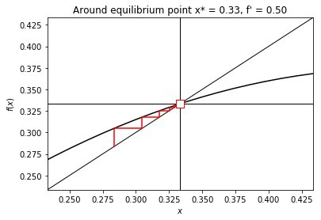

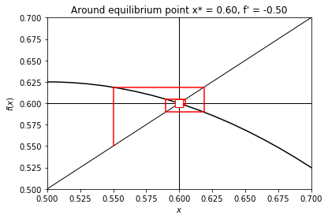

```python
for ri in [1.5, 2.5]:
    print("r = {},".format(ri))
    for xi in equilibrium_points:
        xi = float(xi.subs(r, ri))
        fpi = float(fprime.subs(xt, xi).subs(r, ri))
        is_stable = abs(fpi) < 1
        print("  x* = {:>5.2f} : f' = {:>5.2f} -> equilibrium point is {}stable".format(xi, fpi, '' if is_stable else 'un'))
    focus_equ = xi
    focus_equ_x_tp1 = f_(ri, focus_equ)

    x_in = np.linspace(-0.1, 1.1, 100)
    x_out = f_(ri, x_in)
    # iterate starting from a random point
    x_0 = focus_equ - 0.05 # np.random.rand()
    t = 0
    x_t = x_0
    N = 10
    xx = np.zeros((N,))
    f_ri = f.subs(r, ri)
    for t in range(N):
        xx[t] = x_t
        x_t = float(f_ri.subs(xt, x_t))
    # make a stepping plot of the iterations
    Y = x_0
    plot_x = []
    plot_y = []
    for t in range(N-1):
        X = xx[t]
        plot_x.append(X)
        plot_y.append(Y)
        Y = xx[t+1]
        plot_x.append(X)
        plot_y.append(Y)
    # new figure
    plt.figure()
    plt.plot(x_in, x_out, color='k')
    plt.axhline(linewidth=1, color='k')
    plt.axhline(focus_equ_x_tp1, linewidth=1, color='k')
    plt.axvline(focus_equ, linewidth=1, color='k')
    plt.plot([-1, 1],[-1, 1], color='k', linewidth=1)
    plt.xlim([focus_equ-0.1, focus_equ+0.1])
    plt.ylim([focus_equ_x_tp1-0.1, focus_equ_x_tp1+0.1])
    plt.title("Around equilibrium point x* = {:.2f}, f' = {:.2f}".format(focus_equ, fpi))
    plt.xlabel("$x$")
    plt.ylabel("$f(x)$")
    plt.plot(plot_x, plot_y, color='red')
    plt.scatter(X, Y, marker="s", s=100, edgecolor="red", facecolor="white", zorder=4)
    plot_x.append(Y)
    plot_y.append(Y)
```

Above visible, is the difference between two stable equilibrium points, one where 0 < f' < 1 and one where -1 < f' < 0.

We note that though both are stable, around the stable equilibrium point with f' < 0 we see oscillating ('overshooting') behavior which nonetheless converges, while around the stable equilibrium point with f' > 0, x_t approaches the equilibrium monotonically from one side.

## Problem 2: Logistic growth in continuous time

The logistic model for population growth is:

```python
Lambda = Symbol('lamda')
T = Symbol('t')
X_of_t = Function('x')(T)
K = Symbol('K')
X_0 = Symbol('x_0')
Exp = sympy.exp
```

```python
Dx_dt = Lambda * X_of_t * ( 1 - (X_of_t / K ) )
Df_dx = sympy.diff(Dx_dt, X_of_t)
```

```python
Dx_dt
```

$\displaystyle \lambda \left(1 - \frac{x{\left(t \right)}}{K}\right) x{\left(t \right)}$

> Hint: Use separation of variables and partial fractions.

Separation of variables: $$\int{\lambda dt} = \int{\frac{dx(t)}{x(t)(1 - \frac{x(t)}{K})}}$$

Partial fractions (rhs): $$\int{\frac{K}{x(t) (K - x(t))}dx(t)} = \int{\frac{K - x(t)}{x(t) (K - x(t))} + \frac{x(t)}{x(t) (K - x(t))}dx(t)} = \int{\frac{1}{x(t)}+\frac{1}{K - x(t)}dx(t)}$$

As a result: $$\int{\lambda dt} = \int{\frac{1}{x(t)}dx(t)} + \int{\frac{1}{K - x(t)}dx(t)}$$

Of which all integrals have known solutions: $$\int{\lambda dt} \rightarrow kt + constant$$ $$\int{\frac{1}{x(t)}dx(t)} \rightarrow ln \left | x(t) \right | + constant$$ $$\int{\lambda dt} \rightarrow -ln \left | K - x(t) \right | + constant$$

Thus, $$\lambda t + C = ln \left | x(t) \right | - ln \left | K - x(t) \right | = ln \left | \frac{x(t)}{K - x(t)} \right |$$

Exponential on both sides: $$e^{\lambda t} e^{C} = \left | \frac{x(t)}{K - x(t)} \right |$$

To find exp(C) we set t to 0: $$e^{C} = \left | \frac{x_0}{K - x_0} \right |$$

Thus: $$e^{\lambda t} \left | \frac{x_0}{K - x_0} \right | =\left | \frac{x(t)}{K - x(t)} \right |$$

Multiplying both sides by the r.h.s denominator, and developping: $$(K - x(t)) e^{\lambda t} \frac{\pm x_0}{K - x_0} = x(t),$$

$$K e^{\lambda t} \frac{\pm x_0}{K - x_0} = x(t) + e^{\lambda t} \frac{\pm x_0}{K - x_0} x(t)$$

Which gives: $$x(t) = \frac{K e^{\lambda t} \frac{\pm x_0}{K - x_0}}{1 +e^{\lambda t} \frac{\pm x_0}{K - x_0}}$$

We now multiply the r.h.s denominator and numerator by K - x_0: $$x(t) = \frac{K x_0 e^{\lambda t}}{K - x_0 +e^{\lambda t} x_0}$$

Finally, factorizing x_0 in the r.h.s denominator, we obtain $$x(t) = \frac{K x_0 e^{\lambda t}}{K + x_0 ( e^{\lambda t} - 1) }$$

### (b) Find the equilibrium points of the system and discuss their stability.

The condition for equilibrium is $\frac{dx(t)}{dt} = 0$. Solving the equation yields:

```python
equilibrium_points = sympy.solve(Dx_dt, X_of_t)
print("Equilibrium points are:")
for xi in equilibrium_points:
    print("  x* = {}".format(xi))
```

```
Equilibrium points are:
  x* = 0
  x* = K
```

The condition for a stable equilibrium is $\frac{df}{dx}|_{x=x^*} < 0$.

Let's evaluate $\frac{df}{dx}$ at both equilibrium points.

```python
for xi in equilibrium_points:
    print("Equilibrium point x* = {}, df/dx|x=x*:".format(xi))
    display(Df_dx.subs(X_of_t, xi))
```

```
Equilibrium point x* = 0, df/dx|x=x*:
```

$\displaystyle \lambda$

```
Equilibrium point x* = K, df/dx|x=x*:
```

$\displaystyle - \lambda$

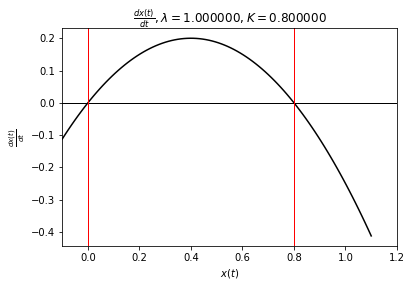

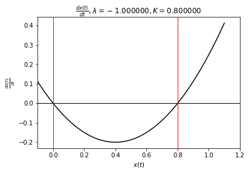

```python
yy = []
xx = np.linspace(-0.1, 1.1, 100)
ll = [1, -1]
ki = 0.8
for li in ll:
    yy = []
    for xi in xx:
      yy.append(Dx_dt.subs(X_of_t, xi).subs(Lambda, li).subs(K, ki))
    yy = np.array(yy)
    plt.figure()
    plt.plot(xx, yy, color='k')
    plt.axhline(linewidth=1, color='k')
    for x_star in equilibrium_points:
      plt.axvline(x_star.subs(K, ki), linewidth=1, color='r')
    plt.xlim([-0.1, 1.2])
    plt.title(r"$\frac{dx(t)}{dt}, \lambda = %f, K = %f$" % (li, ki))
    plt.xlabel(r"$x(t)$")
    plt.ylabel(r"$\frac{dx(t)}{dt}$")
```

We conclude that there exist one stable and one unstable equilibrium, which-is-which depending on whether $\lambda$ is positive or negative.

- For positive lambda, $x^* = 0$ is unstable, while $x^* = K$ is stable.
- For negative lambda, $x^* = 0$ is stable, while $x^* = K$ is unstable.

This makes intuitive sense as for an x slightly away from the equilibrium (let us call epsilon the distance between x and x*), a positive slope in d(dx(t)/dt)/dx(t) means that the change in x is of the same sign as epsilon. Thus, the absolute value of epsilon will increase.

### (c) Numerically integrate to demonstrate the results above.

We will integrate the equation for $K=1$ using RK45.

```python
from scipy.integrate import solve_ivp

def integrate(lam):
    # Integrate the ODE for two different initial conditions
    f = lambda t, x, : lam * x * (1 - x)
    t_span = (0.0, 40.0)

    fig, ax = plt.subplots(1)

    x0 = [0.2]
    sol = solve_ivp(f, t_span, x0)
    ax.plot(sol.t, sol.y.squeeze(), label='$x_0$=0.2')

    x0 = [0.8]
    sol = solve_ivp(f, t_span, x0)
    ax.plot(sol.t, sol.y.squeeze(), label='$x_0$=0.8')

    ax.set_xlabel('$t$')
    ax.set_ylabel('$x(t)$')
    plt.legend()
    plt.show()
```

In case of a positive $\lambda$, the solutions converge to $x^*=K$

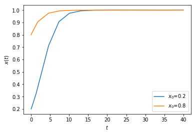

```python
integrate(lam=0.5)
```

In case of a negative $\lambda$, the solutions converge to $x^*=0$.

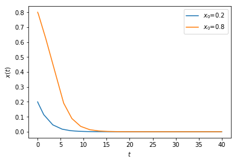

```python
integrate(lam=-0.5)
```

Alternatively, we can integrate the equation using 1st order Euler

$$x_{t+1} = x_{t} + \frac{dx(t_t)}{dt} \Delta t$$ $$t_{t+1} = t_t + \Delta t$$

and trace the iterations:

```
We now numerically integrate with K = 0.8, Lambda = 1, dt = 0.1
```

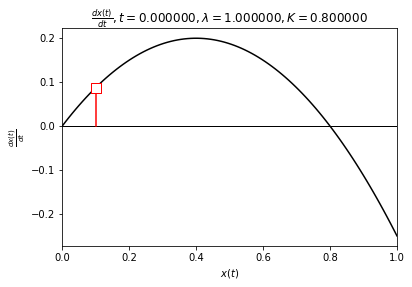

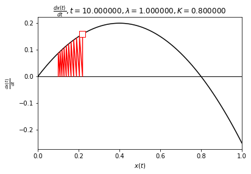

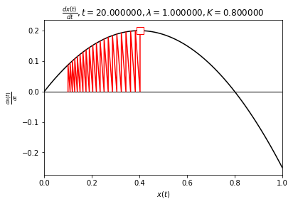

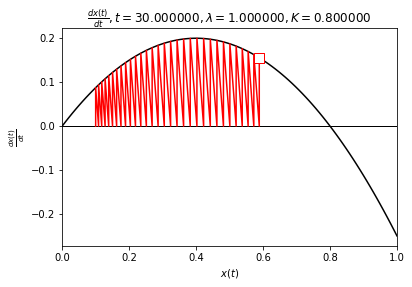

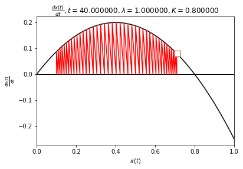

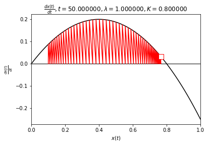

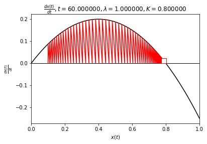

```python
x_axis = np.linspace(0.0, 1.0, 100)
ki = 0.8
li = 1
y_axis = []
for xi in x_axis:
  y_axis.append(Dx_dt.subs(X_of_t, xi).subs(Lambda, li).subs(K, ki))
y_axis = np.array(y_axis)
# iterate starting from a random point
x_0 = 0.1 # np.random.rand()
t = 0
dt = 0.1
x_t = x_0
N = 70
plot_every = 10
xx = np.zeros((N,))
dxx = np.zeros((N,))
for t in range(N):
    xx[t] = x_t
    dxx[t] = float(Dx_dt.subs(K, ki).subs(Lambda, li).subs(X_of_t, x_t))
    x_t = x_t + dxx[t] * dt

print("We now numerically integrate with K = {}, Lambda = {}, dt = {}".format(ki, li, dt))
# make a stepping plot of the iterations
Y = x_0
plot_x = []
plot_y = []
for t in range(N-1):
    X = xx[t]
    Y = dxx[t]
    plot_x.append(X)
    plot_y.append(0)
    plot_x.append(X)
    plot_y.append(Y)
    yy = []
    if t % plot_every == 0:
        plt.figure()
        plt.plot(x_axis, y_axis, color='k')
        plt.axhline(linewidth=1, color='k')
        plt.xlim(0.0, 1.0)
        plt.title(r"$\frac{dx(t)}{dt}, t = %f, \lambda = %f, K = %f$" % (t, li, ki))
        plt.xlabel(r"$x(t)$")
        plt.ylabel(r"$\frac{dx(t)}{dt}$")
        plt.plot(plot_x, plot_y, color='red')
        plt.scatter(X, Y, marker="s", s=100, edgecolor="red", facecolor="white", zorder=4)
    plot_x.append(X + Y * dt)
    plot_y.append(0)
```

As visible above, though x_0 is closer to the equilibrium point a x* = 0, after numerical integration the population ends up converging to x* = K, the only stable equilibrium point (assuming lambda > 0). This result confirms the results in question (b)

Below is the same operation for the case where lambda is negative. We observe that the stability of the equilibrium points are now reversed.

```
We now numerically integrate with K = 0.8, Lambda = -1, dt = 0.1
```

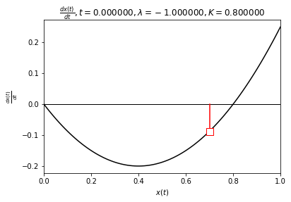

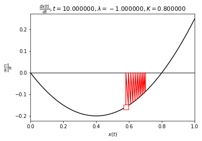

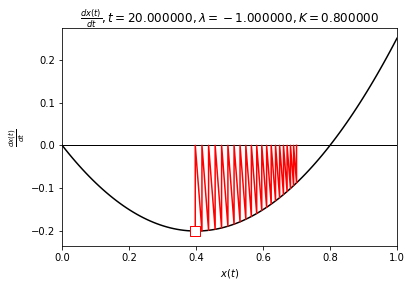

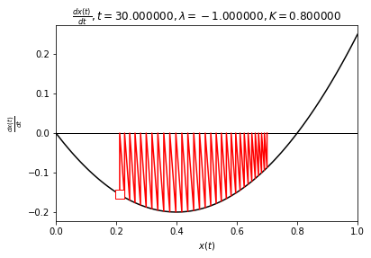

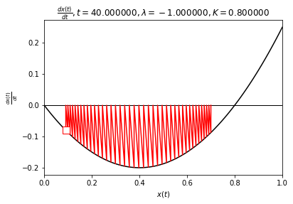

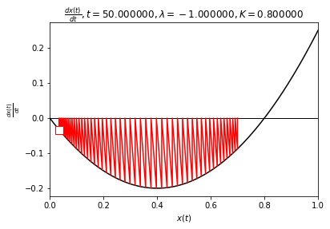

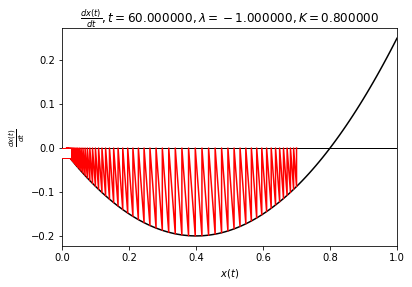

```python
x_axis = np.linspace(0.0, 1.0, 100)
ki = 0.8
li = -1
y_axis = []
for xi in x_axis:
  y_axis.append(Dx_dt.subs(X_of_t, xi).subs(Lambda, li).subs(K, ki))
y_axis = np.array(y_axis)
# iterate starting from a random point
x_0 = 0.7 # np.random.rand()
t = 0
dt = 0.1
x_t = x_0
N = 70
plot_every = 10
xx = np.zeros((N,))
dxx = np.zeros((N,))
for t in range(N):
    xx[t] = x_t
    dxx[t] = float(Dx_dt.subs(K, ki).subs(Lambda, li).subs(X_of_t, x_t))
    x_t = x_t + dxx[t] * dt

print("We now numerically integrate with K = {}, Lambda = {}, dt = {}".format(ki, li, dt))
# make a stepping plot of the iterations
Y = x_0
plot_x = []
plot_y = []
for t in range(N-1):
    X = xx[t]
    Y = dxx[t]
    plot_x.append(X)
    plot_y.append(0)
    plot_x.append(X)
    plot_y.append(Y)
    yy = []
    if t % plot_every == 0:
        plt.figure()
        plt.plot(x_axis, y_axis, color='k')
        plt.axhline(linewidth=1, color='k')
        plt.xlim(0.0, 1.0)
        plt.title(r"$\frac{dx(t)}{dt}, t = %f, \lambda = %f, K = %f$" % (t, li, ki))
        plt.xlabel(r"$x(t)$")
        plt.ylabel(r"$\frac{dx(t)}{dt}$")
        plt.plot(plot_x, plot_y, color='red')
        plt.scatter(X, Y, marker="s", s=100, edgecolor="red", facecolor="white", zorder=4)
    plot_x.append(X + Y * dt)
    plot_y.append(0)
```